# Data Structures and Algorithms Lab 1: Intro to Python

Author

Jackson M Luckey

Published

February 12, 2026

# Objectives

1. Set up a Python environment using `uv` and install Jupyter.
2. Get started with some Python exercises.

# Python Environment

## What is `uv`?

`uv` is a Python package and project manager. It lets you install and manage Python environments and packages.

If you’re familiar with tools like `pip` and `venv`, `uv` integrates all of their functionality into one comprehensive and fast tool.

## Installing `uv`

You can install `uv` with package managers like Homebrew (`brew`) or `WinGet`:

- `brew` on MacOS: `brew install uv`
- `WinGet` on Windows: `winget install --id=astral-sh.uv -e`

or on the command line with

- MacOS/Linux: `curl -LsSf https://astral.sh/uv/install.sh | sh`
- Windows: `powershell -ExecutionPolicy ByPass -c "irm https://astral.sh/uv/install.ps1 | iex"`

I personally recommend using a package manager.

After installing `uv`, make sure that it installed correctly by entering `uv` on the command line. You should see some text printed, starting with “An extremely fast Python package manager”.

```bash
uv
```

If you install `uv` on the command line directly instead of using a package manager, you can update `uv` with `uv self update`. If you installed `uv` with a package manager, `uv` is updated using your package manager’s tooling.

## Installing Python with `uv`

While you can install Python with package manager tools like Homebrew (`brew`) or `WinGet`, `uv` can also be used to manage and install Python.

`uv` is used inside your terminal–the command line interface (CLI) for your computer.

`uv python install` installs the latest Python version (3.14 when I wrote this) and adds it to your `PATH`. Go ahead and run `uv python install`.

```bash
uv python install
```

`uv` can then automatically use the installed version of Python.

You can specify the Python version to install like `uv python install 3.12` (for Python version 3.12). See the [docs](https://docs.astral.sh/uv/concepts/python-versions/#installing-a-python-version) for more details.

You can reinstall all `uv` managed Python installations with `uv python install --reinstall`.

You can view the installed versions of Python with `uv python list`.

## Environments and `uv`

An **environment** is a separate, self-contained workspace. You can think of them as a toolbox: each environment is a separate toolbox, so modifying your tools in one doesn’t affect the others, which allows you to change your tools when working on one project without worrying about its impact on the others. Environments allow you to specify and use a specific version of Python and third-party libraries. By using separate environments per project, you can prevent projects from clashing with one another, and guarantee that when you return to a project, the code you previously wrote works the exact same way. Furthermore, you can share your environment with others, allowing you to make sure that the same version of Python and libraries are used on different machines. These features make environments key for **reproducability**.

In R, you (almost certainly) used a single global environment. When you wanted to use a new package, you installed it using `install.package()`, which installed the package into your system’s R installation. This has some major downsides. As packages/libraries evolve, they often change their functionality, deprecate features, and otherwise change. For example, the `tidyverse` packages like `dplyr` have changed significantly over time. When I first started using R, many–if not most–of the current functions didn’t exist and there were many functions that have since been deprecated. If I was to try to work with my projects from back then, the vast majority of my code wouldn’t even run. This is a huge problem for reproducibality and frustrating–it sucks to spend a lot of time installing different versions of R and R packages and testing your old code to try to get things working again.

In Python, the norm is to use a new environment for every project. These environments are called **virtual environments**. They specify the version of Python and versions of Python packages that a project uses. When you return to a project, you can be sure that you’re using the exact same versions as the last time you worked on the priject. You can then upgrade the versions step by step and test your code as you go rather than hoping that nothing breaks over time.

`uv` manages Python installations and environments using projects. `uv` projects are defined by a `pyproject.toml` file, which specifies which Python version(s) a project supports and what third-party libraries a project uses and what version(s) of the libraries a project supports. You can define a range of versions for both Python and packages. For example, you can say that you need at least version 3.12 of Python or a version of a package falling between 3.1 and 4.10. Other `uv` commands and tools will automatically manage and use the environment you’ve defined. For example, `uv run python` will run a Python program using the relevant virtual environment.

We can create a new `uv` project using the `init` command:

```bash
uv init --bare
```

After creating a project, `uv` automatically creates a persistent virtual environment in a `.venv/` directory next to `pyproject.toml` that it will use when you run commands or scripts with `uv run`. Dependencies declared in `pyproject.toml` will be installed into the virtual environment. When you update `pyproject.toml`, `uv` will automatically update the virtual environment in the `.venv/` directory. I strongly recommend against making modifications to the virtual environment in `.venv/` manually.

You can add a new third-party library to the dependencies field of `pyproject.toml` and therefore install it with `uv add`. By default, this adds the most recent version of the package available compatiable with your Python version and your existing dependencies (i.e. installed packages specified in the dependencies field of `pyproject.toml`) and set the version constraint to that version or greater.

You can specify the version(s) using by including a constraint after the package name and combining the two inside a string. For example, `uv add 'example_package==3.0'` will install version 3.0 of `example_package` and `uv add 'example_package>=3.0'` will install a version greater than or equal to 3.0.

`uv` will automatically handle dependency resolution for you. The exact versions chosen are stored in `uv.lock`, which you should not edit manually. The [lockfile documentation for `uv`](https://docs.astral.sh/uv/concepts/projects/layout/#the-lockfile) has more details, but you don’t need to worry about that for now.

You can remove a package with `uv remove`.

You can add everything specified in a `requirements.txt` file with `uv add -r requirements.txt`. The [`uv` documentation](https://docs.astral.sh/uv/guides/migration/pip-to-project/#importing-requirements-files) provides more information on migrating from a `pip` based project.

The [`uv` depndency management documentation](https://docs.astral.sh/uv/concepts/projects/dependencies/) is useful if you want to learn more.

## Running Python with `uv`

Run Python with `uv` with `uv run python`. As stated earlier, the first time you do this in a project, all dependencies defined in `pyproject.toml` will be installed.

Run a Python script with `uv run python $SCRIPT`, where `$SCRIPT` is your script (a `.py` file). For example `uv run python my_script.py`.

You can open a Python REPL (Read-Eval-Print-Loop), also known as an interactive session, with `uv run python -i`. The `-i` flag stands for interactive.

Test it out by opening a Python REPL:

```bash
uv run python -i
```

and printing “Hello World”:

```python
>>> print("Hello World")
Hello World
```

[as students learning new programming languages have done for 50+ years](https://en.wikipedia.org/wiki/%22Hello,_World!%22_program).

You can close the Python shell using the `quit()` function.

You can launch an IPython shell using `uv run ipython`. This is a nicer shell that comes with better autocomplete, syntax highlighting, and help accessed via `?` like RStudio’s console. I would recommend using the IPython shell instead of the built-in Python REPL.

## Jupyter

Another option is to use Jupyter **notebooks**, which is an interactive document that allows you to combine Python code, Markdown, and output like tables and figures. Jupyter notebooks use **kernels**, which are language-specific Jupyter implementions. The Python kernel for Jupyter is built on top of IPython.

Jupyter notebooks are stored as files with the `.ipynb` file extension. These files are fundamentally JSON (a way of storing data as text–don’t worry if you’re unfamiliar with the term) and store the data you’re working with and your **state**. Storing state means that changes you’ve made, such as defining variables and functions, will persist by default. Watch out for this–reopening a Jupyter notebook does not clear state automatically so it’s easy to make something unreproducable.

Jupyter has to be installed (i.e. you need to run `uv add jupyter`) in your project to be used. It will automatically install IPython as well.

You can launch a Jupyter notebook by running `jupyter notebook` in your command line. By default, this will open up a notebook in your web browser. Some IDEs, including VS Code and Positron, also support Jupyter notebooks.

I personally dislike Jupyter notebooks, but they’re the de facto lingua franca of data science and are commonly used and are an excellent tool for experimentation.

Let’s go ahead and add Jupyter to this project.

```bash
uv add jupyter
```

# VS Code and Positron

Last semester you used RStudio as your IDE (Integrated Development Environment). While it’s possible to write Python code with RStudio, I would strongly recommend using either VS Code or Positron.

[VS Code](https://code.visualstudio.com/) is a free and mostly open-source IDE developed by Microsoft. [Over 75% of developers use VS Code](https://survey.stackoverflow.co/2025/technology/#1-dev-id-es).

[Positron](https://positron.posit.co/) is a IDE developed by Posit–the same company that makes RStudio–that is designed specifically for doing data science with R and Python. It’s built on top of the open-source core of VS Code and is compatible with many VS Code extensions and shares most of VS Code’s features. [Here are the installation instructions](https://positron.posit.co/install.html). You can also install Positron with Homebrew (`brew`) on MacOS, which is what I do. [You can read the documentation for Positron here](https://positron.posit.co/welcome.html). [Posit also provides a guide for switching from RStudio to Positron](https://positron.posit.co/migrate-rstudio.html).

[PyCharm](https://www.jetbrains.com/pycharm/) is another popular option for Python, but I haven’t used it enough to be very helpful.

I personally use Positron for most data science tasks and will be using it for most of our bootcamp. Let’s do a quick tour of Positron.

## Positron Tour

Positron and RStudio have fairly similar interfaces.

[figure not shown]

Comparison of RStudio’s and Positron’s interfaces. From [Positron’s Migrating from RStudio](https://positron.posit.co/migrate-rstudio.html) guide.

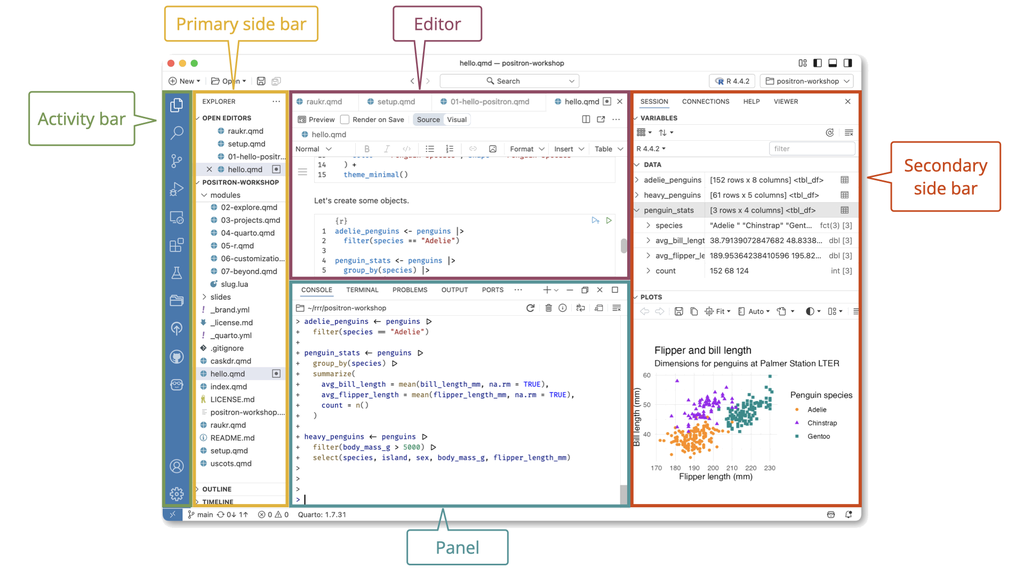

Positron’s interface. From [Positron’s Migrating from RStudio](https://positron.posit.co/migrate-rstudio.html) guide.

The activity bar controls what is shown in the primary side bar. It defaults to the explorer, which shows the currently open workspace. Workspaces are the same idea as a R project. They can contain one or more folders, although I typically keep everything inside one root directory.

The other options that you’ll likely use today are

- Search: find and replace in your current file or across files in your workspace.
- Source control: use `git`, such as making commits and branches.
- GitHub: pull requests and issues.

Pressing your currently open icon in the activity bar toggles the display of the primary side bar.

The editor is for modifying files, such as Python/R scripts.

The panel is your console, which includes

- Console: R and Python Read-Eval-Print-Loops (REPLs), which are for interactive use.
- Terminal: your system’s command line interface (CLI).

Both the console and terminal can have multiple tabs, which are shown on the right by default.

The secondary side bar shows the variables in your current Python and R sessions in the console, the plots you’ve generated, help and documentation (think of `?thing_you_want_docs_for` in RStudio), and your console history (every piece of code you’ve executed so far).

Positron and VSCode both have command palettes. If you press “View” in your menubar, the first item should show the shortcut for pulling up the command palette. On MacOS it is `shift`-`command`-`P`. The command palette lets you execute most of the commands/functions in your IDE using their names.

# Intro to Python

Like R, Python can be used as a glorified calculator. Common operators include `+`, `-`, `/`, `*`, `**` (exponentiation), and `%` (modulo, or remainder division).

```python
>>> 5 + 5
10
>>> 5 * 5
25
>>> 1 / 3
0.3333333333333333
>>> 2 ** 8
256
```

Variables are assigned using `=`. Variable names can only use letters, numbers, and underscores (`_`).

```python
>>> width = 10
>>> height = 5
>>> width * height
50
```

Lists are a common **data structure**. They’re an ordered collection of items. You can create a list by putting comma-separated items inside brackets. You can access elements inside a list by providing an index or a range of indices. Python counts from 0, unlike R. When providing a range of indices, the starting value is inclusive and the ending valye is exclusive.

```python
>>> cities = ['Berlin', 'Paris', 'London', 'Tokyo']
>>> cities[0]
'Berlin'
>>> cities[1]
'Paris'
>>> cities[0:3]
['Berlin', 'Paris', 'London']
```

You can add a new element to the end of a list using the `append()` method and add a list of elements to an existing list with the `extend()` method.

```python
>>> cities
['Berlin', 'Paris', 'London', 'Tokyo']
>>> cities.append('Shanghai')
>>> cities
['Berlin', 'Paris', 'London', 'Tokyo', 'Shanghai']
>>> cities.extend(['Barcelona', 'Athens'])
>>> cities
['Berlin', 'Paris', 'London', 'Tokyo', 'Shanghai', 'Barcelona', 'Athens']
```

You can **iterate** through the elements in a list using a `for` loop.

```python
>>> for city in cities:
...     print(city)
Berlin
Paris
London
Tokyo
Shanghai
Barcelona
Athens
```

You can create and manipulate lists using comprehensions. A **comprehension** iterates through a **sequence** and returns a new sequence. The general syntax for a list comprehension is `[expression for item in iterable if condition]`. The `if condition` clause applies to `item` and not `expression`. I’ll show examples using the `range()` function, which creates a sequence of integers.

```python
>>> [x for x in range(10)]
[0, 1, 2, 3, 4, 5, 6, 7, 8, 9]
>>> [x for x in range(10) if x % 2 == 0]
[0, 2, 4, 6, 8]
>>> [2 * x for x in range(10)]
[0, 2, 4, 6, 8, 10, 12, 14, 16, 18]
>>> [2 * x for x in range(10) if x % 2 == 0]
[0, 4, 8, 12, 16]
>>> [x ** 2 for x in range(10)]
[0, 1, 4, 9, 16, 25, 36, 49, 64, 81]
```

You can get the length of a list using the `len()` function and the sum (of a list of numbers) using the `sum()` function.

```python
>>> numbers = [x for x in range(10)]
>>> len(numbers)
10
>>> sum(numbers)
45
```

Python has `if`, `else`, and `elif` (else if). Comparisons can be combined using `and` and `or`.

Python can print f-strings, which are strings beginning with a `f`. You can include Python expressions inside f-strings by wrapping them in curly braces.

```python
>>> numbers = [x for x in range(10)]
>>> for number in numbers:
...     if number == 0:
...         print(f'{number} is zero')
...     elif number % 2 == 0:
...         print(f'{number} is even')
...     else:
...         print(f'{number} is odd')
0 is zero
1 is odd
2 is even
3 is odd
4 is even
5 is odd
6 is even
7 is odd
8 is even
9 is odd
```

Functions are defined using the `def` keyword. Functions can take input. Functions are terminated by the `return` keyword, which returns an object.

```python
>>> def is_odd(x):
...     return x % 2 != 0

>>> is_odd(2)
False
>>> is_odd(5)
True
>>> [is_odd(x) for x in range(10)]
[False, True, False, True, False, True, False, True, False, True]
>>> [x for x in range(10) if is_odd(x)]
[1, 3, 5, 7, 9]
```

# Exercises

## Exercise 1

Create a function `is_even(x)` that returns `True` if `x` is even and `False` otherwise.

**TipSolution for Exercise 1**

```python
def is_even(x):
    return x % 2 == 0
```

Congratulations–you can now write the Python equivalent of a [JavaScript package with almost 200k downloads a week](https://www.npmjs.com/package/is-even)!

## Exercise 2

Write a function that takes an integer $x$ > 1 as an input and returns the sum of all integers 1 to $x$, including $x$.

**TipSolution for Exercise 2**

You can loop through the integers and add each integer to a running sum:

```python
def sum_integers(x):
    current_sum = 0
    for i in range(1, x + 1):
        current_sum += i
    return current_sum
```

Or use a list comprehension to make a list of the integers and `sum()` the list.

```python
def sum_integers(x):
    integers = [x for x in range(1, x + 1)]
    return sum(integers)
```

```python
>>> sum_integers(10)
55
>>> sum_integers(100)
5050
```

## Exercise 3

Write a function that checks if an integer is a multiple of another integer.

**TipSolution for Exercise 3**

```python
def is_multiple(a, b):
    return a % b == 0
```

```python
>>> is_multiple(10, 2)
True
>>> is_multiple(3, 2)
False
>>> is_multiple(35, 7)
True
>>> is_multiple(7, 2)
False
```

## Exercise 4

Write a function that takes an integer $x$ > 1 as an input and returns the sum of all integers 1 to $x$, including $x$, where $x$ is a multiple of 2, 3, or 5.

**TipSolution for Exercise 4**

```python
def sum_of_multiples(x):
    return sum([
        x
        for x in range(1, x + 1)
        if is_multiple(x, 2) or is_multiple(x, 3) or is_multiple(x, 5)
    ])
```

```python
>>> sum_of_multiples(10)
47
>>> sum_of_multiples(100)
3782
>>> sum_of_multiples(500)
91582
```

## Exercise 5

Leap years contain an additional day, February 29, to keep the calendar year in sync with the astronomical year. As per [Wikipedia](https://en.wikipedia.org/wiki/Leap_year#Gregorian_calendar):

> Every year that is exactly divisible by four is a leap year, except for years that are exactly divisible by 100, but these centurial years are leap years if they are exactly divisible by 400.

Implement a function that takes `year` and returns `True` if `year` is a leap year and `False` otherwise.

As an aside, [messing this up has happened quite a few times](https://en.wikipedia.org/wiki/Leap_year_problem). Excel famously implements leaps years incorrectly to maintain backwards compatiability with previous spreadsheet software that did it wrong.

**TipSolution for Exercise 5**

You can break the conditions out into separate `if`, `elif`, and `else` statements.

```python
def is_leap_year(year):
    if year % 400 == 0:
        return True
    elif year % 100 == 0:
        return False
    elif year % 4 == 0:
            return True
    else:
        return False
```

Or combine them into a single line.

```python
def is_leap_year(year):
    return (year % 4 == 0) and not ((year % 100 == 0) and not (year % 400 == 0))
```

```python
>>> is_leap_year(2000)
True
>>> is_leap_year(1433)
False
>>> is_leap_year(1900)
False
```

## Exercise 6

Implement a function that takes a list of years and returns a count of leap years. Use this function to calculate the number of leap years from 0 to 2026. How out of sync would the calendar and astronomical date be without leap years?

**TipSolution for Exercise 6**

```python
def count_leap_years(years):
    return sum([is_leap_year(year) for year in years])
```

```python
>>> years = [x for x in range(2027)]
>>> count_leap_years(years)
492
>>> count_leap_years(years) % 365
127
```

**1**

Number of leap years between 0 and 2026.

**2**

How many days the calendar would be out of sync. We use modulo here because being 365 days out of sync is the same as being back in sync.

## Exercise 7

The Fibonacci sequence came up in lecture when Drew recommend using its values for story/experience points. The Fibonacci sequence is a sequence of numbers where each element is the sum of the two elements that precede it. The Fibonacci numbers are $F_0 = 0$, $F_1 = 1$, and $F_n = F_{n - 1} + F_{n - 2}$ for $n > 1$.

Implement a function that returns the $n$-th Fibonacci number ($F_n$).

**TipSolution for Exercise 7**

```python
def fibonacci_number(n):
    if n <= 1:
        return n
    prev, curr = 0, 1
    for i in range(2, n + 1):
        prev, curr = curr, prev + curr
    return curr
```

**1**

The first two elements are 0 and 1.

**2**

Set the previous number to 0 and the current number to 1.

**3**

```python
>>> fibonacci_number(0)
0
>>> fibonacci_number(1)
1
>>> fibonacci_number(10)
55
>>> for ii in range(10):
...     print(f'F_{ii} = {fibonacci_number(ii)}')
F_0 = 0
F_1 = 1
F_2 = 1
F_3 = 2
F_4 = 3
F_5 = 5
F_6 = 8
F_7 = 13
F_8 = 21
F_9 = 34
```

## Exercise 8

**TipSolution for Exercise 8**

Using the `fibonacci_number()` function to create a list of the first $n$ Fibonacci numbers:

```python
def fibonacci_sequence(n):
    return [fibonacci_number(n) for n in range(n + 1)]
```

Creating the list as we calculate each subsequent Fibonacci number:

```python
def fibonacci_sequence(n):
    if n == 0:
        return [0]
    if n == 1:
        return [0, 1]
    prev, curr = 0, 1
    sequence = [prev, curr]
    for i in range(2, n + 1):
        prev, curr = curr, prev + curr
        sequence.append(curr)
    return sequence
```

## Exercise 9

Calculate the sum of the Fibonacci sequence up to $F_n$ for $n = [0, 1, 2 \dots 20]$.

**TipSolution for Exercise 9**

```python
>>> [sum(fibonacci_sequence(n)) for n in range(21)]
[0,
 1,
 2,
 4,
 7,
 12,
 20,
 33,
 54,
 88,
 143,
 232,
 376,
 609,
 986,
 1596,
 2583,
 4180,
 6764,
 10945,
 17710]
```

## Exercise 10

Take the Fibonacci sequence up to $F_{50}$. Create separate lists for the even and odd elements. How many even elements are there? How many odd elements are there? What are the sums of the two lists?

**TipSolution for Exercise 10**

```python
>>> sequence = fibonacci_sequence(50)

>>> evens = [x for x in sequence if x % 2 == 0]
>>> len(evens)
17
>>> sum(evens)
6293134512

>>> odds = [x for x in sequence if x % 2 != 0]
>>> len(odds)
34
>>> sum(odds)
26658145586
```